# Capstone

Read data and assign to *appointments*

```r
appointments <- read.csv("Final_Data.csv")
zipcodes <- read.csv("zipcodes.csv")
```

### Data Summary and Structure

```
##   keptstatus          date              time            length
##  Kept  :288246   4/11/17:  1300   13:00:00: 40627   Min.   : 10
##  Missed: 54616   4/13/17:  1300   8:00:00 : 36476   1st Qu.: 60
##                  4/18/17:  1282   10:00:00: 35541   Median : 60
##                  4/19/17:  1282   11:00:00: 34899   Mean   : 57
##                  4/12/17:  1280   14:00:00: 34440   3rd Qu.: 60
##                  5/2/17 :  1272   9:00:00 : 33510   Max.   :600
##                  (Other):335146   (Other) :127369
##    datesched           age             gender
##  7/11/17:  1588   Min.   :  0.00   Female :190399
##  5/1/17 :  1327   1st Qu.: 17.00   Male   :152061
##  5/2/17 :  1288   Median : 34.00   Other  :    76
##  5/3/17 :  1236   Mean   : 35.56   Unknown:   326
##  5/8/17 :  1202   3rd Qu.: 54.00
##  5/30/17:  1198   Max.   :264.00
##  (Other):335023
##            billtype        priormiss         priorkept
##  Commercial    : 78296   Min.   :  0.000   Min.   :  0.00
##  DMAP          :264565   1st Qu.:  1.000   1st Qu.:  2.00
##  To Be Assigned:     1   Median :  2.000   Median :  6.00
##                          Mean   :  2.451   Mean   :  8.02
##                          3rd Qu.:  3.000   3rd Qu.: 11.00
##                          Max.   :117.000   Max.   :676.00
##
##     distance           zip         specialty
##  Min.   :   0.0   AP     : 29129   A:246965
##  1st Qu.:   0.0   BL     : 22388   B: 84147
##  Median :   3.0   BT     : 17440   C:  5623
##  Mean   :  10.8   BH     : 13337   D:  5512
##  3rd Qu.:   9.0   AF     : 10887   E:    42
##  Max.   :2688.0   AJ     : 10816   F:   525
##  NA's   :974      (Other):238865   G:    48
##                  remindresult
##  Answered - No Response:180874
##  Not Called            : 63501
##  Answered - Confirmed  : 49108
##  Failed                : 27944
##  Left Message          : 18433
##  Answered - Reschedule :  1369
##  (Other)               :  1633
```

```
## 'data.frame':    342862 obs. of  14 variables:
##  $ keptstatus  : Factor w/ 2 levels "Kept","Missed": 1 1 1 1 2 1 1 1 1 1 ...
##  $ date        : Factor w/ 361 levels "1/10/17","1/10/18",..: 320 320 320 320 320 320 320 320 320 320 ...
##  $ time        : Factor w/ 89 levels "0:00:00","10:00:00",..: 65 78 78 78 78 78 78 78 78 78 ...
##  $ length      : int  90 60 120 60 60 60 60 60 60 90 ...
##  $ datesched   : Factor w/ 1475 levels "1/10/12","1/10/13",..: 1242 39 618 1120 1089 1141 1148 1363 1332 387 ...
##  $ age         : int  7 75 31 45 49 71 49 38 36 13 ...
##  $ gender      : Factor w/ 4 levels "Female","Male",..: 2 1 2 2 2 2 2 1 2 2 ...
##  $ billtype    : Factor w/ 3 levels "Commercial","DMAP",..: 2 1 2 2 1 2 1 1 2 2 ...
##  $ priormiss   : int  1 2 1 6 5 6 8 0 2 3 ...
##  $ priorkept   : int  3 5 5 15 6 6 20 0 5 12 ...
##  $ distance    : int  41 29 5 5 0 5 0 539 0 4 ...
##  $ zip         : Factor w/ 50 levels "AA","AB","AC",..: 16 38 38 38 38 38 38 38 45 34 ...
##  $ specialty   : Factor w/ 7 levels "A","B","C","D",..: 1 1 1 2 2 1 1 1 2 1 ...
##  $ remindresult: Factor w/ 9 levels "Answered - Canceled",..: 7 2 7 3 3 2 7 9 9 3 ...
```

Convert time and date variables to POSIXct Convert zip to character

```r
appointments$time <- as.POSIXct(appointments$time, format = "%H:%M:%S")
appointments$date <- as.POSIXct(appointments$date, format = "%m/%d/%y")
appointments$datesched <- as.POSIXct(appointments$datesched,
                                     format = "%m/%d/%y")
###appointments$zip <- as.character(appointments$zip)
```

Calculating percent of missed appointments overall

```r
missed_rate <- length(which(appointments$keptstatus == "Missed")) /
    length(appointments$keptstatus)
missed_rate
```

```
## [1] 0.1592944
```

### Build Data Dictionary using dataMeta

```r
var_desc <- c("Dependent Variable Kept or Missed", "Appointment Date",
              "Appointment Time", "Appointment Length in Minutes",
              "Date Appointment was scheduled", "Patient Age", "Patient Gender",
              "Billing Type", "Number of prior missed appointments",
              "Number of prior kept appointments",
              "Patient Distance From Office in Miles",
              "Office Zip Code - Anonymized","Provider Primary Specialty",
              "Reminder Call result")
var_type <- c(1, 0, 0, 0, 0, 0, 1, 1, 0, 0, 0, 1, 1, 1)
linker <- dataMeta::build_linker(appointments, variable_description = var_desc,
                                 variable_type = var_type)
dictionary <- dataMeta::build_dict(my.data = appointments, linker = linker,
                                   option_description = NULL,
                                   prompt_varopts = FALSE)
knitr::kable(dictionary, format = "html",
             caption = "Data Dictionary for Original Dataset")
```

Data Dictionary for Original Dataset

| variable_name | variable_description | variable_options |
| --- | --- | --- |
| age | Patient Age | 0 to 264 |
| billtype | Billing Type | DMAP |
|  |  | Commercial |
|  |  | To Be Assigned |
| date | Appointment Date | 2016-09-01 to 2018-01-31 |
| datesched | Date Appointment was scheduled | 2011-10-18 to 2018-01-31 |
| distance | Patient Distance From Office in Miles | NA to NA |
| gender | Patient Gender | Male |
|  |  | Female |
|  |  | Other |
|  |  | Unknown |
| keptstatus | Dependent Variable Kept or Missed | Kept |
|  |  | Missed |
| length | Appointment Length in Minutes | 10 to 600 |
| priorkept | Number of prior kept appointments | 0 to 676 |
| priormiss | Number of prior missed appointments | 0 to 117 |
| remindresult | Reminder Call result | Left Message |
|  |  | Answered - Confirmed |
|  |  | Answered - No Response |
|  |  | Not Called |
|  |  | Failed |
|  |  | Answered - Reschedule |
|  |  | No Answer |
|  |  | Busy |
|  |  | Answered - Canceled |
| specialty | Provider Primary Specialty | A |
|  |  | B |
|  |  | G |
|  |  | C |
|  |  | D |

[output cut: 53 more lines]

### Data Exploration

#### age

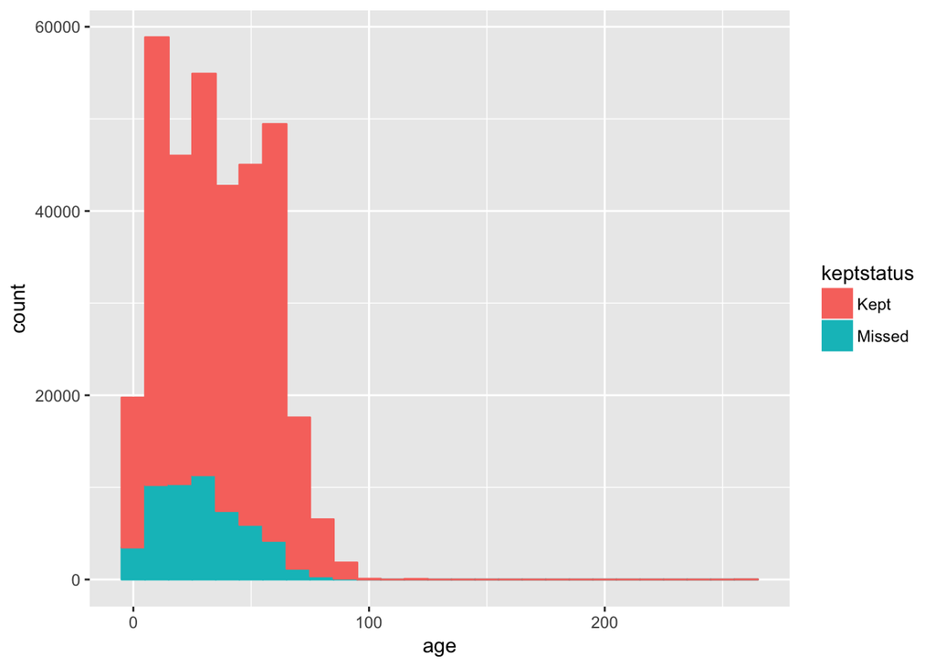

```r
ggplot(appointments, aes(x = age, group = keptstatus, col = keptstatus,
                         fill = keptstatus)) +
    geom_histogram(binwidth = 10)
```

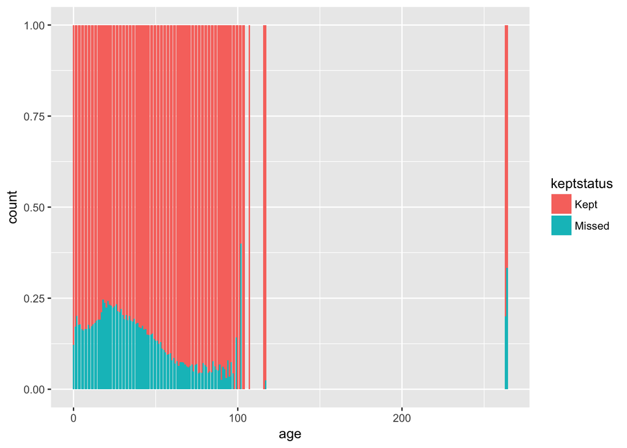

```r
ggplot(data = appointments) +
    geom_bar(mapping = aes(x = age, fill = keptstatus), position = "fill")
```

Ranges from 0-264, so there are obviously some impossible values. Ratio of missed appointments decreases with age in general.

Removing obervations of ages greater than 100, creating categorical age groups and replotting.

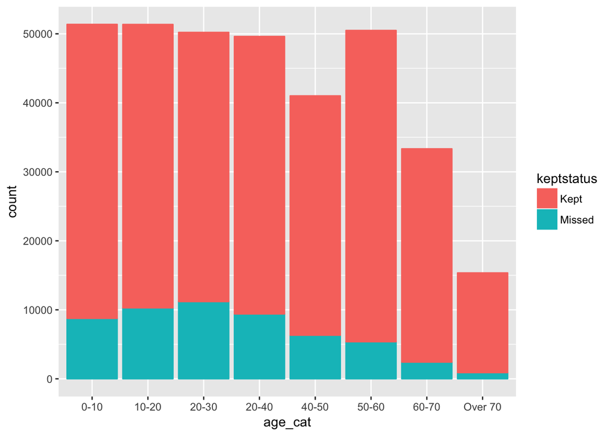

```r
appointments_2 <- appointments %>%
    filter(age <= 100)

appointments_2 <- appointments_2 %>%
    mutate(age_cat = cut(age, breaks = c(-1, 10, 20, 30, 40, 50, 60, 70, 101),
                         labels = c("0-10", "10-20", "20-30", "20-40", "40-50",
                                    "50-60", "60-70", "Over 70")))


ggplot(appointments_2, aes(x = age_cat, group = keptstatus, col = keptstatus,
                           fill = keptstatus)) +
    stat_count()
```

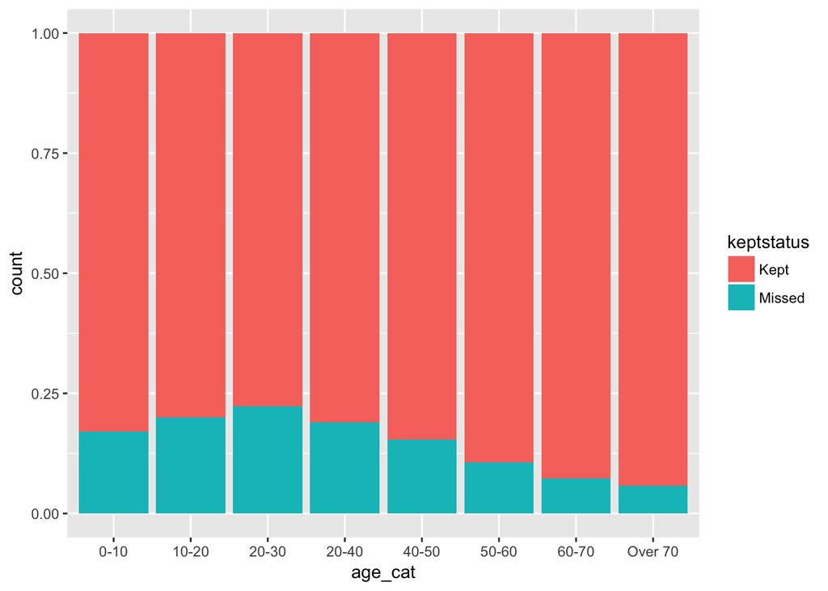

```r
ggplot(data = appointments_2) +
    geom_bar(mapping = aes(x = age_cat, fill = keptstatus), position = "fill")
```

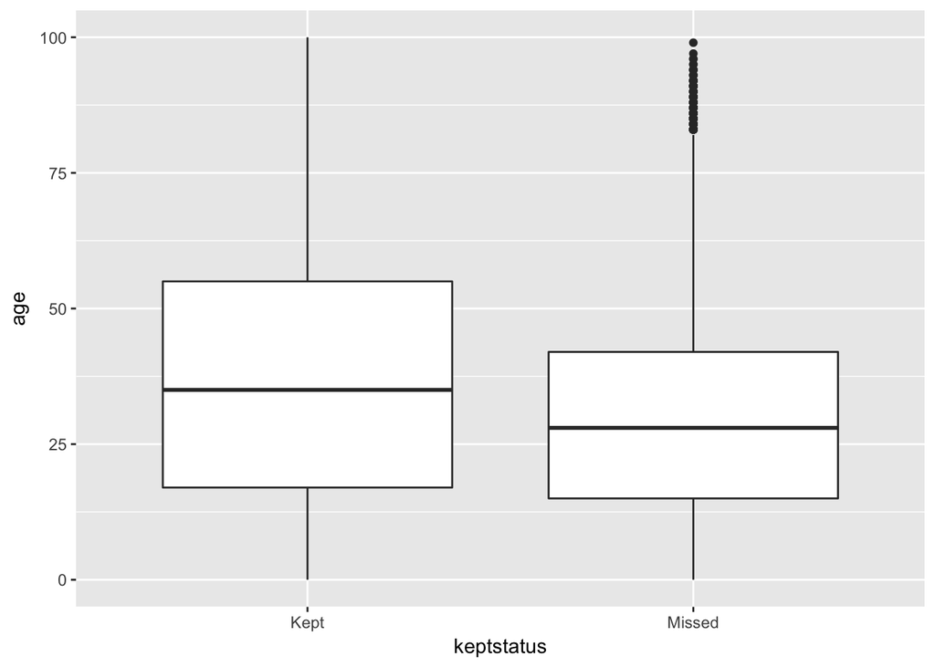

```r
ggplot(data = appointments_2, aes(x = keptstatus, y = age)) +
    geom_boxplot()
```

#### billtype

```r
table(appointments_2$billtype)
```

```
##
##     Commercial           DMAP To Be Assigned
##          78278         264486              1
```

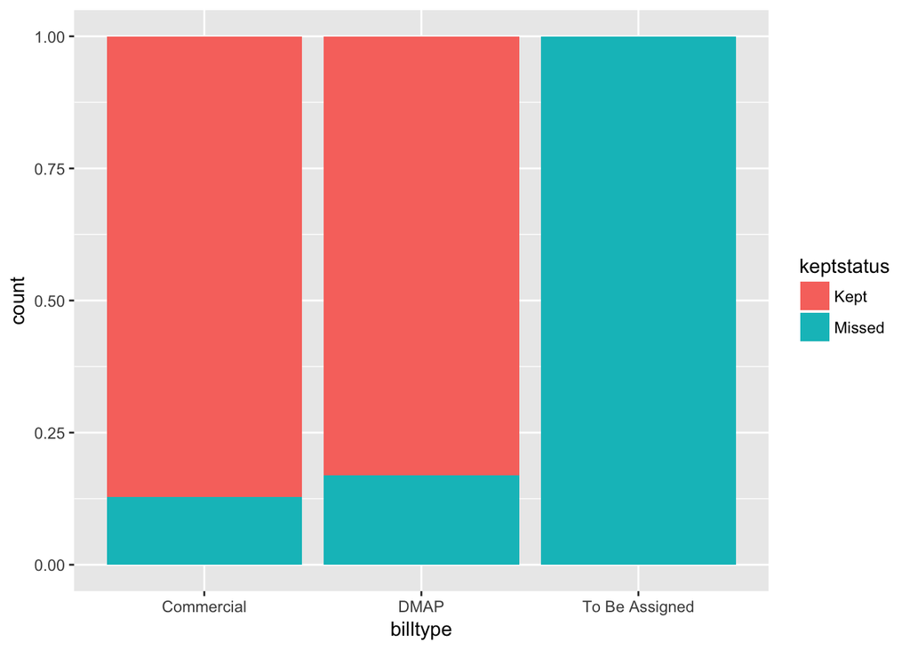

```r
ggplot(data = appointments_2) +
    geom_bar(mapping = aes(x = billtype, fill = keptstatus), position = "fill")
```

Only one row has *To Be Assigned* value and will just be removed There is a minor difference between billing types

```r
appointments_2 <- subset(appointments_2,
                           appointments_2$billtype != "To Be Assigned")
```

#### time

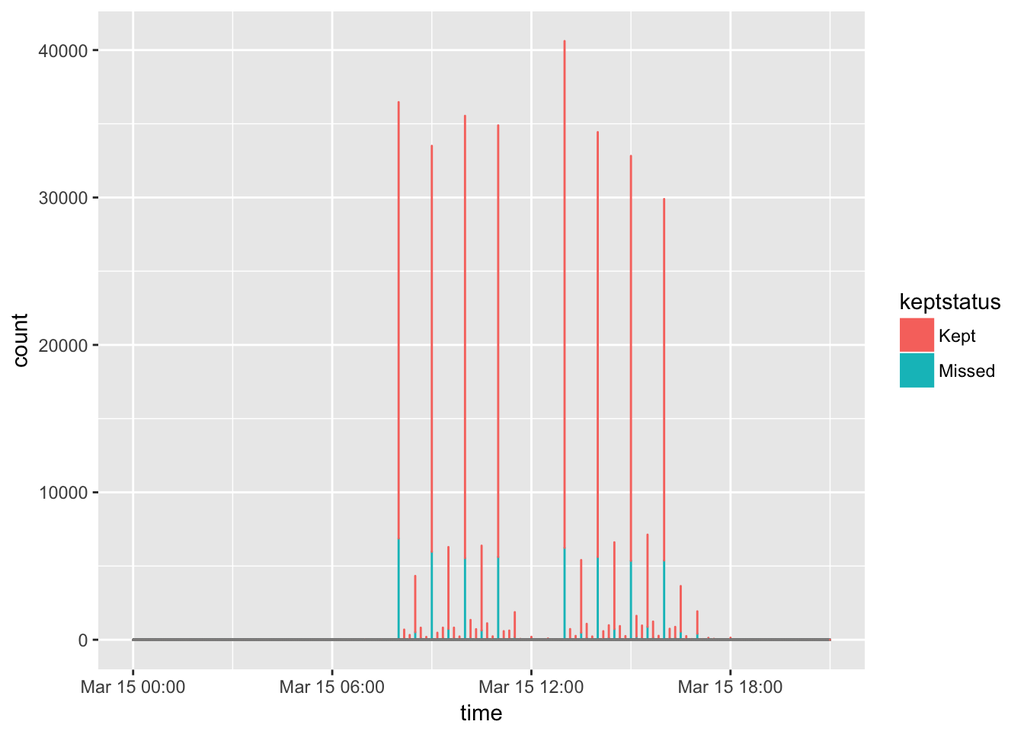

```r
ggplot(data = appointments_2,
       aes(x = time, group = keptstatus, col = keptstatus, fill = keptstatus)) +
    geom_histogram(binwidth = 1)
```

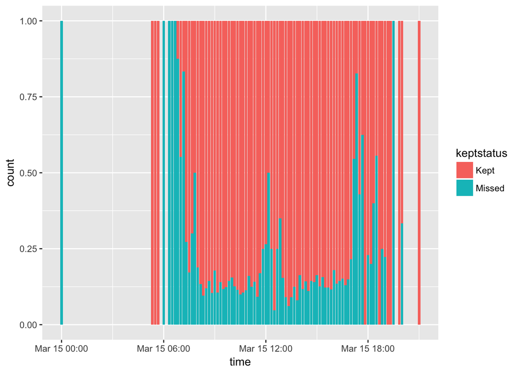

```r
ggplot(data = appointments_2) +
    geom_bar(mapping = aes(x = time, fill = keptstatus), position = "fill")
```

Creating new *hour* variable and replotting

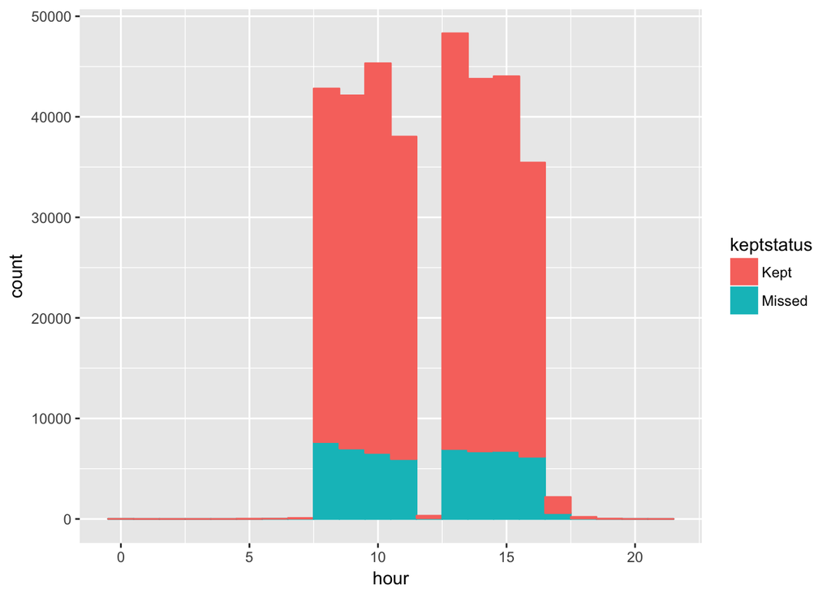

```r
appointments_2 <- appointments_2 %>%
    mutate(hour = lubridate::hour(appointments_2$time))

ggplot(data = appointments_2,
       aes(x = hour, group = keptstatus, col = keptstatus, fill = keptstatus)) +
    geom_histogram(binwidth = 1)
```

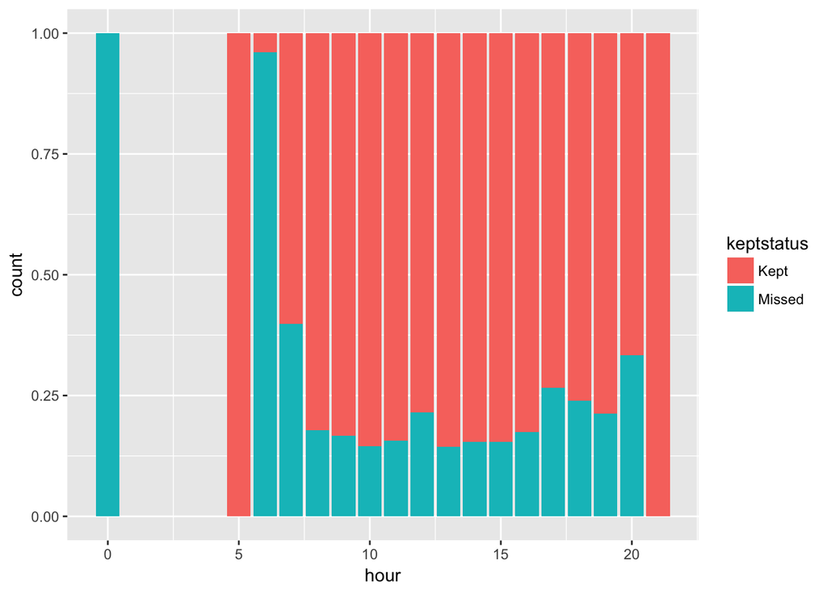

```r
ggplot(data = appointments_2) +
    geom_bar(mapping = aes(x = hour, fill = keptstatus), position = "fill")
```

Ranges from 00:00:00 to 21:00:00. More appointments are missed in the early morning, late afternoon and early evening, and around lunchtime, however, there are very few appointments at these times. During main scheduling periods, the variation is minor.

#### remindresult

```r
table(appointments_2$remindresult)
```

```
##
##    Answered - Canceled   Answered - Confirmed Answered - No Response
##                    152                  49108                 180860
##  Answered - Reschedule                   Busy                 Failed
##                   1369                   1104                  27943
##           Left Message              No Answer             Not Called
##                  18429                    377                  63422
```

Low counts of “Answered - Cancelled”, “Answered - Reschedule”, “Busy”, and “No Answer”

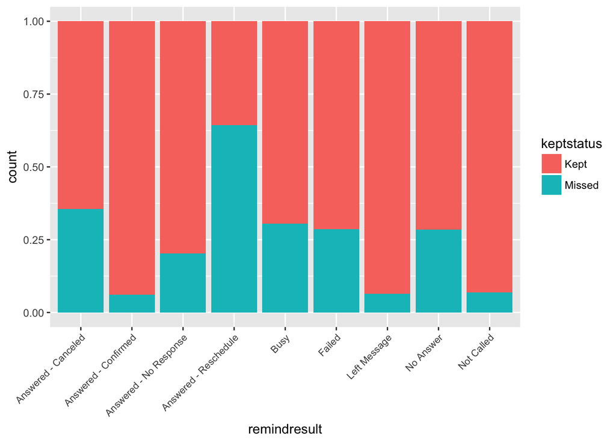

```r
ggplot(data = appointments_2) +
    geom_bar(aes(x = remindresult, fill = keptstatus), position = "fill") +
    theme(axis.text.x = element_text(size = 8, angle = 45,
                                     hjust = 1, vjust = 1))
```

Comments: ~65% of appointments with “Answered - Cancelled” and ~35% with “Answered-Reschedule” still kept their appointments, however, very few observations in these categories.

#### specialty

```r
table(appointments_2$specialty)
```

```
##
##      A      B      C      D      E      F      G
## 246904  84114   5619   5512     42    525     48
```

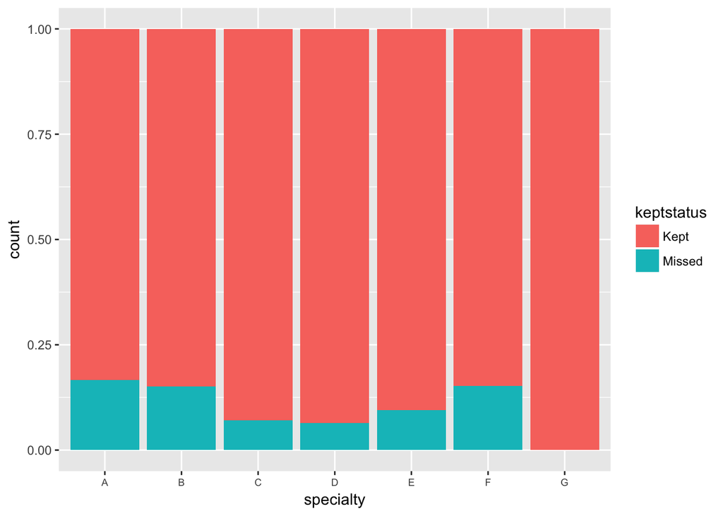

```r
ggplot(data = appointments_2) +
    geom_bar(aes(x = specialty, fill = keptstatus), position = "fill") +
    theme(axis.text.x = element_text(size = 7))
```

C, D, and E provider specialties have lower proportion of missed appointments,

#### length

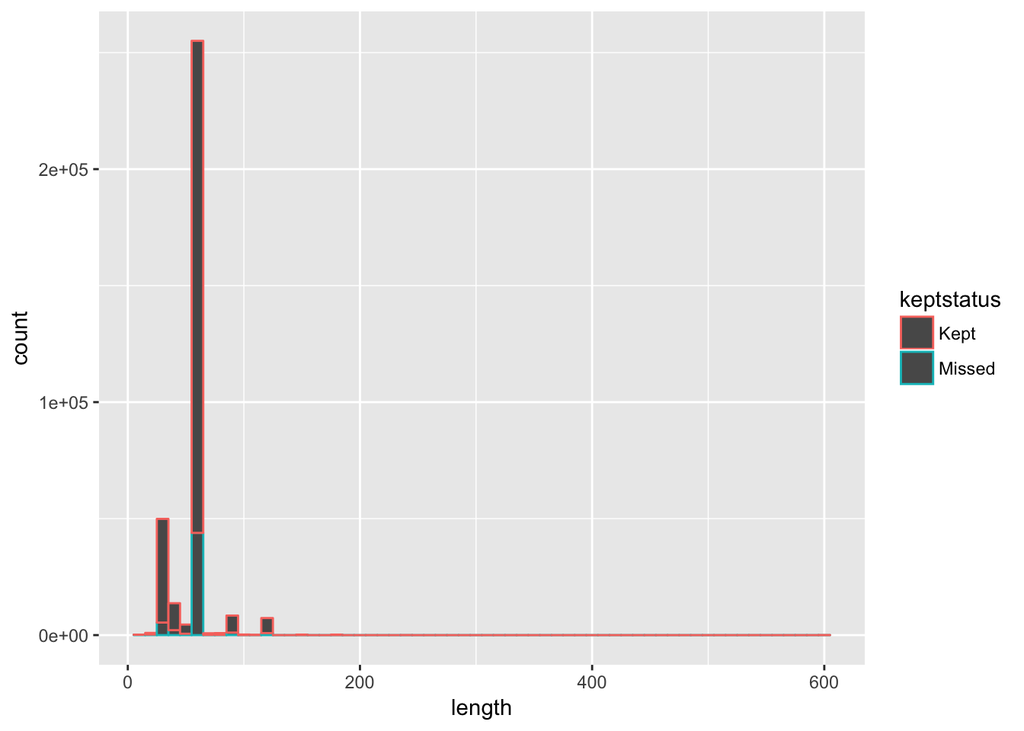

```r
ggplot(appointments_2, aes(x = length, group = keptstatus, col = keptstatus)) +
    geom_histogram(binwidth = 10)
```

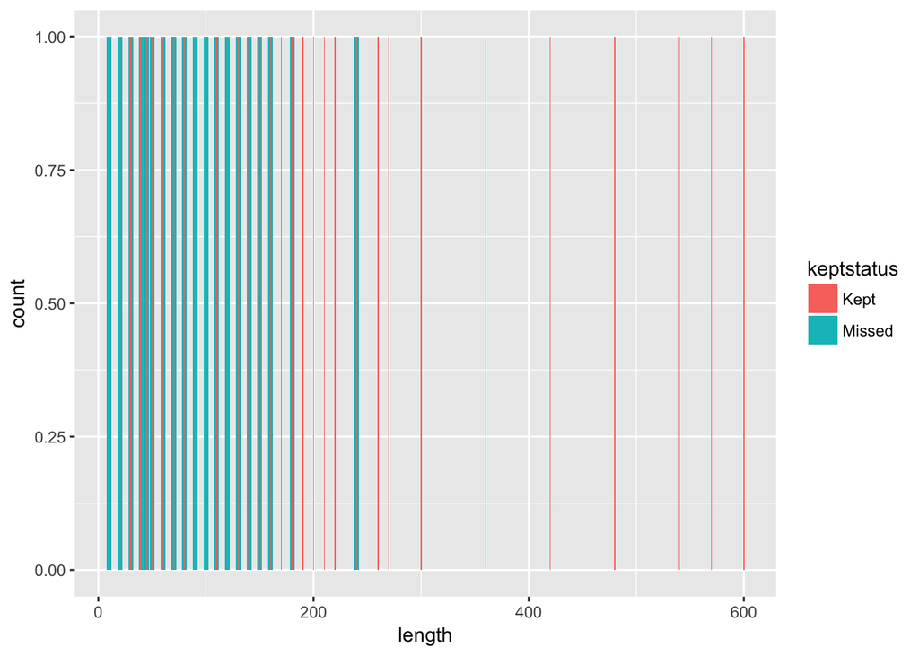

```r
ggplot(data = appointments_2) +
    geom_bar(mapping = aes(x = length, fill = keptstatus), position = "fill")
```

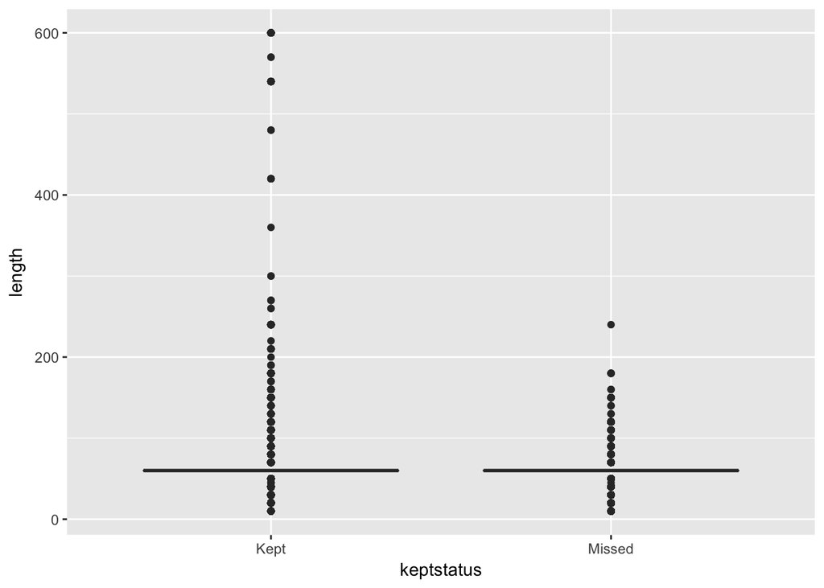

```r
ggplot(data = appointments_2, aes(x = keptstatus, y = length)) +
    geom_boxplot()
```

#### distance

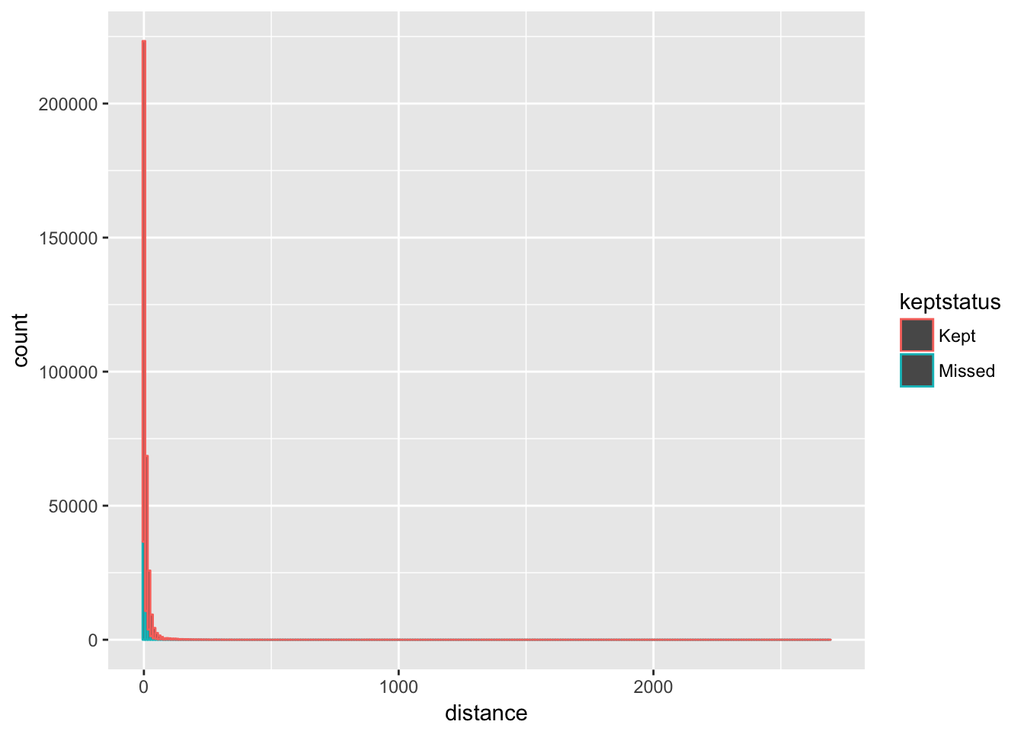

```r
ggplot(appointments_2, aes(x = distance, group = keptstatus, col = keptstatus)) +
    geom_histogram(binwidth = 10)
```

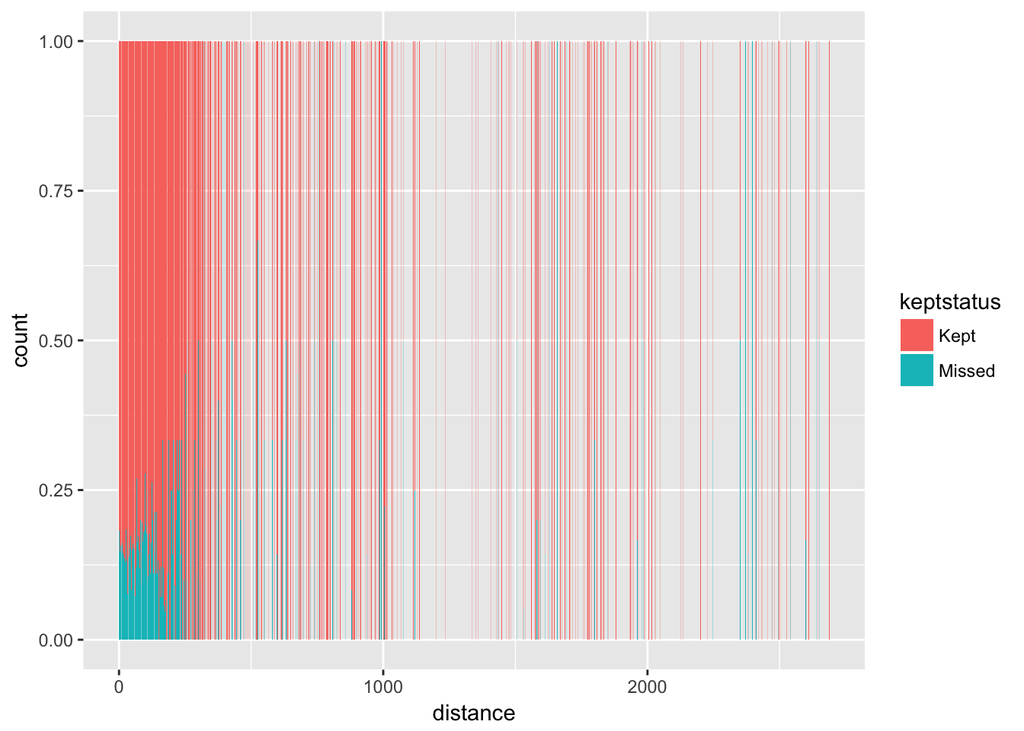

```r
ggplot(data = appointments_2) +
    geom_bar(mapping = aes(x = distance, fill = keptstatus), position = "fill")
```

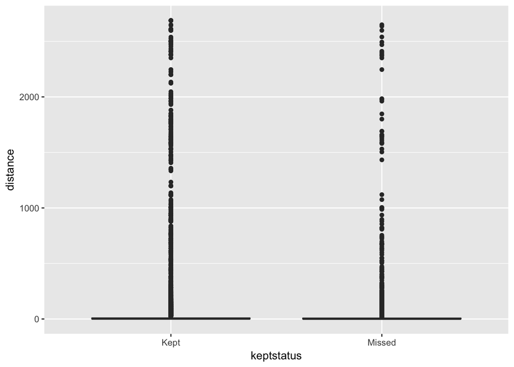

```r
ggplot(data = appointments_2, aes(x = keptstatus, y = distance)) +
    geom_boxplot()
```

Create new variables

percent_missed = percent of prior appointments missed.

```r
appointments_3 <- appointments_2 %>%
    mutate(missed = ifelse(appointments_2$keptstatus == "Missed", 1,0)) %>%
    mutate(percent_missed = priormiss / (priormiss + priorkept)) %>%
    mutate(new = ifelse(appointments_2$priormiss == 0 & appointments_2$priorkept == 0, 1, 0)) %>%
    mutate(leadtime = as.integer((date - datesched)/86400)) %>% #results are in seconds. Should convert to days for simplicity
    mutate(weekday = as.factor(strftime(date, "%A")))
#remove zipcodes$zip <- as.character(zipcodes$zip)
appointments_3 <- dplyr::left_join(appointments_3, zipcodes, by = "zip")
str(appointments_3)
```

```
## 'data.frame':    342764 obs. of  23 variables:
##  $ keptstatus    : Factor w/ 2 levels "Kept","Missed": 1 1 1 1 2 1 1 1 1 1 ...
##  $ date          : POSIXct, format: "2016-09-01" "2016-09-01" ...
##  $ time          : POSIXct, format: "2018-03-15 05:30:00" "2018-03-15 08:00:00" ...
##  $ length        : int  90 60 120 60 60 60 60 60 60 90 ...
##  $ datesched     : POSIXct, format: "2016-08-01" "2016-01-18" ...
##  $ age           : int  7 75 31 45 49 71 49 38 36 13 ...
##  $ gender        : Factor w/ 4 levels "Female","Male",..: 2 1 2 2 2 2 2 1 2 2 ...
##  $ billtype      : Factor w/ 3 levels "Commercial","DMAP",..: 2 1 2 2 1 2 1 1 2 2 ...
##  $ priormiss     : int  1 2 1 6 5 6 8 0 2 3 ...
##  $ priorkept     : int  3 5 5 15 6 6 20 0 5 12 ...
##  $ distance      : int  41 29 5 5 0 5 0 539 0 4 ...
##  $ zip           : Factor w/ 50 levels "AA","AB","AC",..: 16 38 38 38 38 38 38 38 45 34 ...
##  $ specialty     : Factor w/ 7 levels "A","B","C","D",..: 1 1 1 2 2 1 1 1 2 1 ...
##  $ remindresult  : Factor w/ 9 levels "Answered - Canceled",..: 7 2 7 3 3 2 7 9 9 3 ...
##  $ age_cat       : Factor w/ 8 levels "0-10","10-20",..: 1 8 4 5 5 8 5 4 4 2 ...
##  $ hour          : int  5 8 8 8 8 8 8 8 8 8 ...
##  $ missed        : num  0 0 0 0 1 0 0 0 0 0 ...
##  $ percent_missed: num  0.25 0.286 0.167 0.286 0.455 ...
##  $ new           : num  0 0 0 0 0 0 0 1 0 0 ...
##  $ leadtime      : int  31 226 210 85 65 51 49 0 2 663 ...
##  $ weekday       : Factor w/ 5 levels "Friday","Monday",..: 3 3 3 3 3 3 3 3 3 3 ...
##  $ county        : Factor w/ 24 levels "A","B","C","D",..: 16 9 9 9 9 9 9 9 20 12 ...
##  $ size          : int  2 4 4 4 4 4 4 4 4 4 ...
```

#### percent_missed

Create random subset and plot

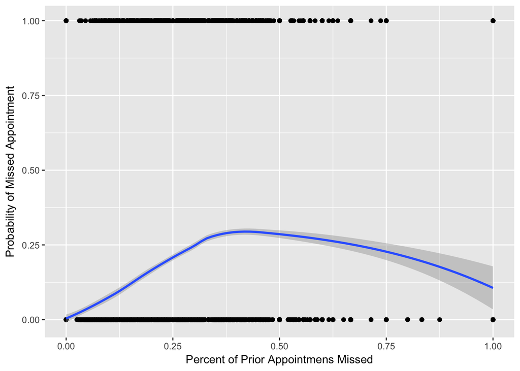

```r
appointments_sample_05 <- appointments_3 %>%
    sample_frac(size = 0.05, replace = FALSE)

ggplot(data = appointments_sample_05, aes(x = percent_missed, y = missed)) +
    geom_point() +
    stat_smooth(method = "loess") +
    xlab("Percent of Prior Appointmens Missed") +
    ylab("Probability of Missed Appointment")
```

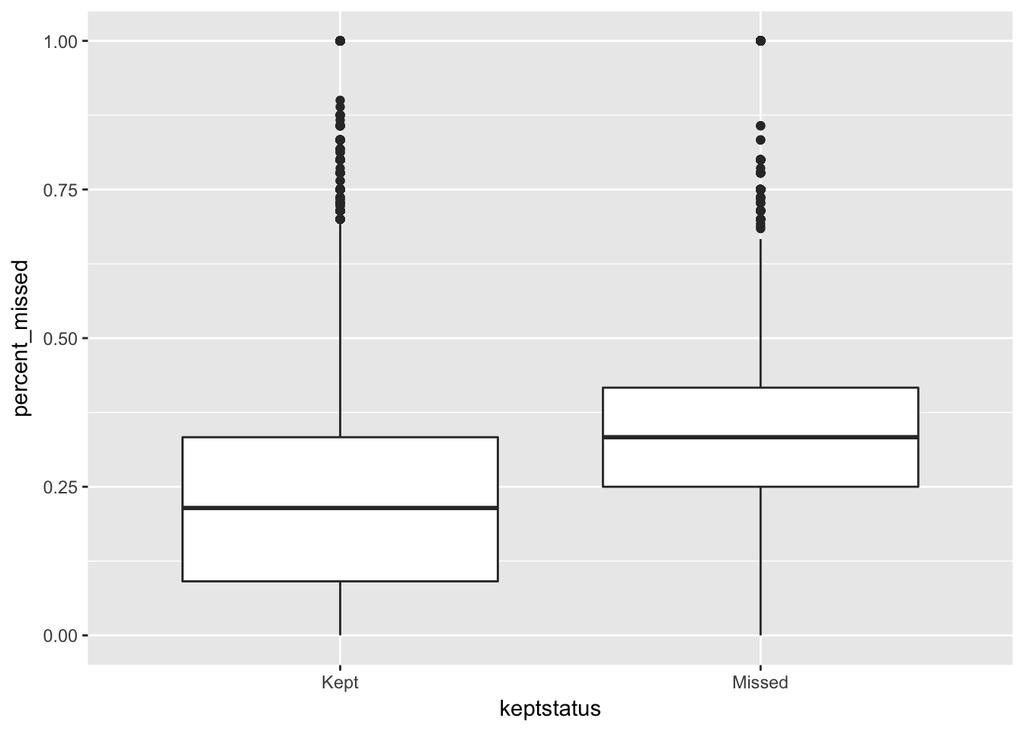

```r
ggplot(data = appointments_3, aes(x = keptstatus, y = percent_missed)) +
    geom_boxplot()
```

#### New

```r
table(appointments_3$new)
```

```
##
##      0      1
## 320426  22338
```

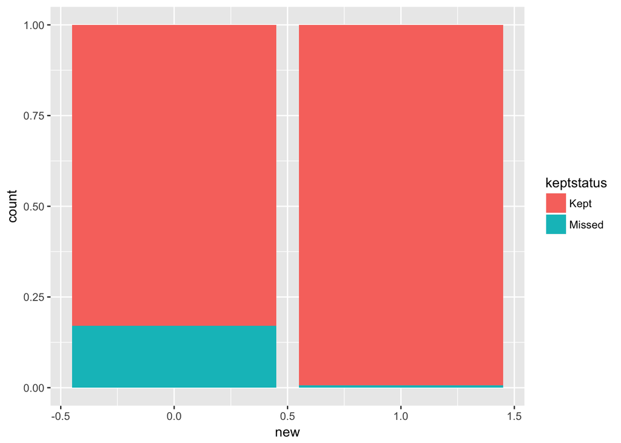

```r
ggplot(data = appointments_3) +
    geom_bar(mapping = aes(x = new, fill = keptstatus), position = "fill")
```

New patients have a very high percentage of kept appointments. 22k of 342k appointments are first-time, or about 6.4%

#### Time Differential

```r
table(appointments_3$new)
```

```
##
##      0      1
## 320426  22338
```

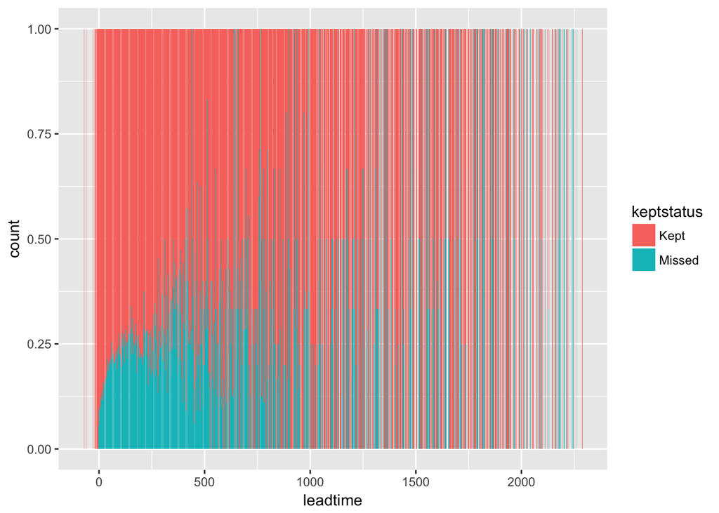

```r
ggplot(data = appointments_3) +
    geom_bar(mapping = aes(x = leadtime, fill = keptstatus), position = "fill")
```

#### Size

```r
table(appointments_3$new)
```

```
##
##      0      1
## 320426  22338
```

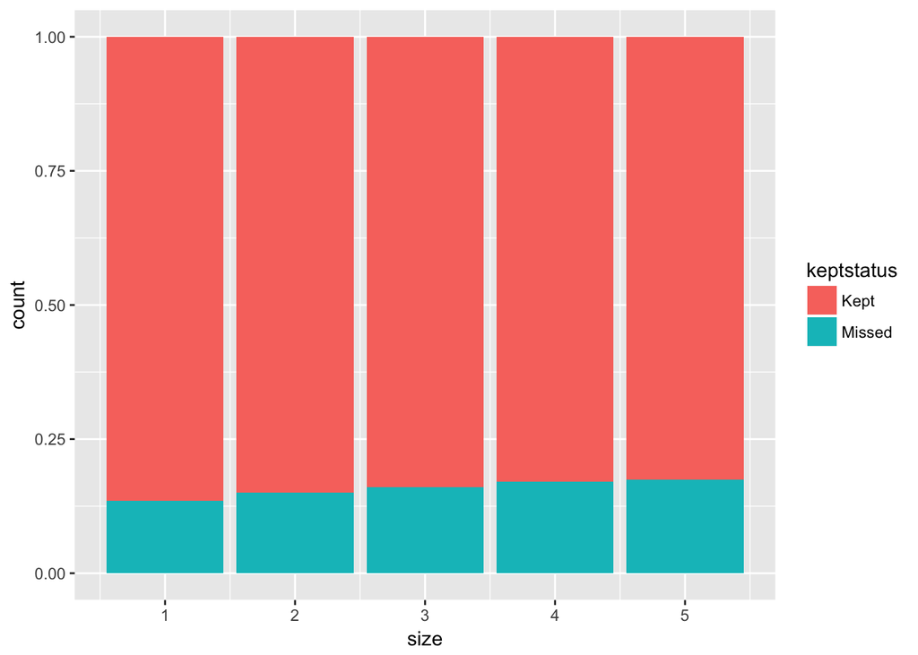

```r
ggplot(data = appointments_3) +
    geom_bar(mapping = aes(x = size, fill = keptstatus), position = "fill")
```

#### County

```r
table(appointments_3$new)
```

```
##
##      0      1
## 320426  22338
```

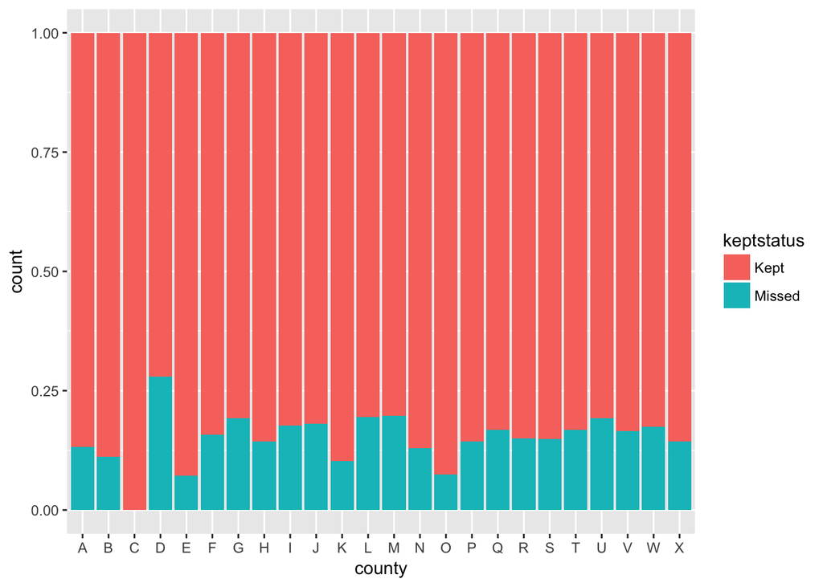

```r
ggplot(data = appointments_3) +
    geom_bar(mapping = aes(x = county, fill = keptstatus), position = "fill")
```

### Modeling

Create Modeling Data

```r
mod_data <- appointments_3 #%>%
mod_data$new <- as.factor(mod_data$new)
mod_data$percent_missed <- as.integer(mod_data$percent_missed * 100)
#Replace NAs with mean
mod_data$percent_missed <- mod_data$percent_missed %>%
    tidyr::replace_na(mean(mod_data$percent_missed, na.rm = TRUE))

#Check for NAs
sapply(mod_data, function(x) sum(is.na(x)))
```

```
##     keptstatus           date           time         length      datesched
##              0              0              0              0              0
##            age         gender       billtype      priormiss      priorkept
##              0              0              0              0              0
##       distance            zip      specialty   remindresult        age_cat
##            972              0              0              0              0
##           hour         missed percent_missed            new       leadtime
##              0              0              0              0              0
##        weekday         county           size
##              0              0              0
```

```r
## Distance hase 972 NA values, will replace with mean
mod_data$distance <- mod_data$distance %>%
    tidyr::replace_na(median(mod_data$distance, na.rm = TRUE))

str(mod_data)
```

```
## 'data.frame':    342764 obs. of  23 variables:
##  $ keptstatus    : Factor w/ 2 levels "Kept","Missed": 1 1 1 1 2 1 1 1 1 1 ...
##  $ date          : POSIXct, format: "2016-09-01" "2016-09-01" ...
##  $ time          : POSIXct, format: "2018-03-15 05:30:00" "2018-03-15 08:00:00" ...
##  $ length        : int  90 60 120 60 60 60 60 60 60 90 ...
##  $ datesched     : POSIXct, format: "2016-08-01" "2016-01-18" ...
##  $ age           : int  7 75 31 45 49 71 49 38 36 13 ...
##  $ gender        : Factor w/ 4 levels "Female","Male",..: 2 1 2 2 2 2 2 1 2 2 ...
##  $ billtype      : Factor w/ 3 levels "Commercial","DMAP",..: 2 1 2 2 1 2 1 1 2 2 ...
##  $ priormiss     : int  1 2 1 6 5 6 8 0 2 3 ...
##  $ priorkept     : int  3 5 5 15 6 6 20 0 5 12 ...
##  $ distance      : num  41 29 5 5 0 5 0 539 0 4 ...
##  $ zip           : Factor w/ 50 levels "AA","AB","AC",..: 16 38 38 38 38 38 38 38 45 34 ...
##  $ specialty     : Factor w/ 7 levels "A","B","C","D",..: 1 1 1 2 2 1 1 1 2 1 ...
##  $ remindresult  : Factor w/ 9 levels "Answered - Canceled",..: 7 2 7 3 3 2 7 9 9 3 ...
##  $ age_cat       : Factor w/ 8 levels "0-10","10-20",..: 1 8 4 5 5 8 5 4 4 2 ...
##  $ hour          : int  5 8 8 8 8 8 8 8 8 8 ...
##  $ missed        : num  0 0 0 0 1 0 0 0 0 0 ...
##  $ percent_missed: num  25 28 16 28 45 ...
##  $ new           : Factor w/ 2 levels "0","1": 1 1 1 1 1 1 1 2 1 1 ...
##  $ leadtime      : int  31 226 210 85 65 51 49 0 2 663 ...
##  $ weekday       : Factor w/ 5 levels "Friday","Monday",..: 3 3 3 3 3 3 3 3 3 3 ...
##  $ county        : Factor w/ 24 levels "A","B","C","D",..: 16 9 9 9 9 9 9 9 20 12 ...
##  $ size          : int  2 4 4 4 4 4 4 4 4 4 ...
```

Divide rf_sample into train, validate, and test sets

```r
###split <- sample(3, nrow(rf_sample), replace = TRUE, prob = c(0.60, 0.20, 0.20))
train <- mod_data[1:205660,]
validate <- mod_data[205660:274200,]
test <- mod_data[274201:nrow(mod_data),]

table(train$keptstatus)
```

```
##
##   Kept Missed
## 174601  31059
```

```r
train2 <- train[168738:205660,]
table(train2$keptstatus)
```

```
##
##   Kept Missed
##  31059   5864
```

```r
train_kept <- train2[train2$keptstatus == "Kept",]
train_missed <- train[train$keptstatus == "Missed",]

train_balanced <- rbind(train_kept, train_missed)
table(train_balanced$keptstatus)
```

```
##
##   Kept Missed
##  31059  31059
```

### Logistic Regression Model

```r
model1 <- caret::train(keptstatus ~ age + remindresult + specialty + billtype + hour + percent_missed + length + gender + distance + new + leadtime + weekday + county, data = train_balanced, method = "glm")
model1$finalModel
confusionMatrix(model1)
##p_glm <- predict(glm, train)
#caret::confusionMatrix(p_glm, train$kept_status)
```

### Random Forest Model

Using randomForest Package

```r
rf <- randomForest(keptstatus ~ age + remindresult + specialty + billtype + hour + percent_missed + length + gender + distance + new + leadtime + weekday + county, data = train_balanced, ntree = 250)
#Takes about 30 seconds to run
```

Using caret Package

```r
# Look at number of cvs and repeats for faster run-time
control <- caret::trainControl(method = "repeatedcv", number = 10, repeats = 3)
seed <- 7
metric <- "Accuracy"
set.seed(seed)
mtry <- 3
tunegrid <- expand.grid(.mtry = mtry)

#Train on subset to see how long it will take.  Takes ~ 1.5 hours
```

```r
rftrain <- caret::train(keptstatus ~ age + remindresult + specialty + billtype + hour + percent_missed + length + gender + distance + new + leadtime + weekday + county, data = train_balanced, method = "rf", metric = metric, tuneGrid = tunegrid, trControl = control)
```

```r
caret::confusionMatrix(rftrain)
```

```r
control <- caret::trainControl(method = "repeatedcv", number = 10, repeats = 3, search = "random")
seed <- 7
metric <- "Accuracy"
set.seed(seed)
mtry <- 3
tunegrid <- expand.grid(.mtry = mtry)
```

```r
### Below code takes a long time to run, need to consider ways to shorten it
rftrain3 <- caret::train(keptstatus ~ age + remindresult + specialty +
                         billtype + hour + percent_missed + length + gender +
                         distance + new + leadtime + weekday + county,
                         data = train_balanced, method = "rf", metric = metric,
                         tuneLength = 15, trControl = control)
```

```r
print(rftrain2)
plot(rf)
varImpPlot(rf)
varUsed(rf)
p_rf <- predict(rf, test)
caret::confusionMatrix(p_rf, test$keptstatus)
```